# 36-315 Homework 04, Fall 2021

SOLUTIONS

Due Tuesday, September 28, 2021 (11:59pm ET) on Gradescope

## Homework 04: Assessing Quantitative Distributions with Histograms, Density Estimates, and Boxplots

# Problem 1: Describing Distributions with Histograms and Density Plots (22 points)

In Homework3, we worked with The Guardian’s “1000 Songs to Hear Before You Die” dataset. We’re going to work with that dataset again in this problem; here’s the code to load in the dataset (as well as fix issues with the `YEAR` variable, which we saw in Homework3):

```r
#read in the data
songs = read.csv("https://raw.githubusercontent.com/zjbranson/315Fall2021/master/1000songs.csv")
#clean the year variable
songs$YEAR = as.numeric(gsub(",","",songs$YEAR))
```

In Homework3, we focused on the `decade` of songs instead of the individual `YEAR`. In other words, we categorized a quantitative variable. In this homework, we’ll recognize that `YEAR` is a quantitative variable that can be plotted with histograms.

1. (6pts) Using `geom_histogram()`, create a histogram of `YEAR`, where you specify a value for `binwidth` that you think is appropriate. Defend your choice in 1-2 sentences. Make sure your histogram has appropriate titles/labels and a non-default color. Then, describe the marginal distribution of `YEAR` in 1-3 sentences.

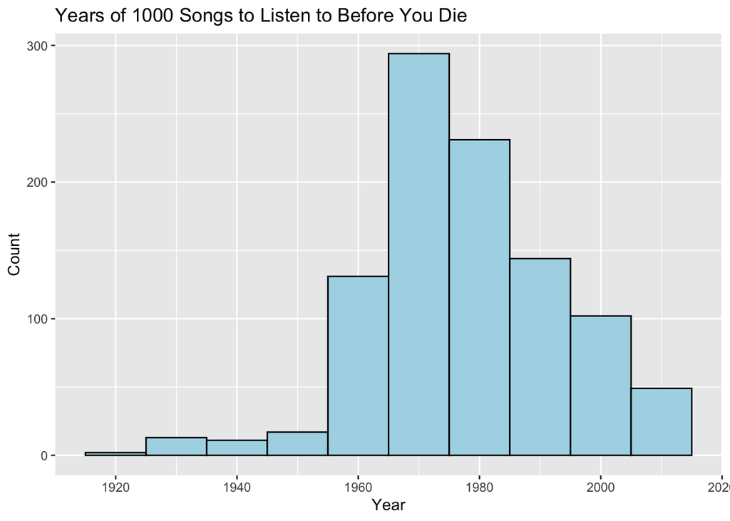

```r
library(tidyverse)
ggplot(data = songs, aes(x = YEAR)) +
  geom_histogram(binwidth = 10, color = "black", fill = "lightblue") + labs(title = "Years of 1000 Songs to Listen to Before You Die", x = "Year", y = "Count")
```

*Here we chose `binwidth = 10`, because as a result, each bar represents a one-decade period, which is intuitive for this dataset where we are visualizing the years of songs. Furthermore, we tried several `binwidth` choices, and found that this choice does not obfuscate any notable characteristics of the `YEAR` distribution. From this graph, we can see that `YEAR` is centered around 1975—this is intuitive when we consider that the critics who made this list in 2009 were likely growing up during the 1970s. The distribution seems to be nearly symmetric and Normally distributed, except that it has a slight left skew for years before 1955, suggesting that these critics were not too fond (or more likely, not too familiar) with songs written before 1955.*

2. (6pts) In this part, make the exact same graph you made in Part A, but with these changes:
- Add a smoothed density to the histogram using `geom_density()`. Be sure to add `aes(y = ..density..)` within `geom_histogram()`.
- Add a vertical line at the mean of `YEAR`. (If you can’t remember how to add a vertical line, revisit Homework01.)
- Make sure that the histogram bars `fill`, smoothed density line, and vertical line all have different colors.
- Make sure the title and labels are appropriate.

After you’ve made your plot, answer the following question. If you tried to just use `geom_density()` *without* adding `aes(y = ..density..)` within `geom_histogram()`, you wouldn’t be able to see the density curve overlayed on top of the histogram. Why is that? Explain in 1-2 sentences. (**Hint**: Try getting rid of `aes(y = ..density..)` and see what happens.)

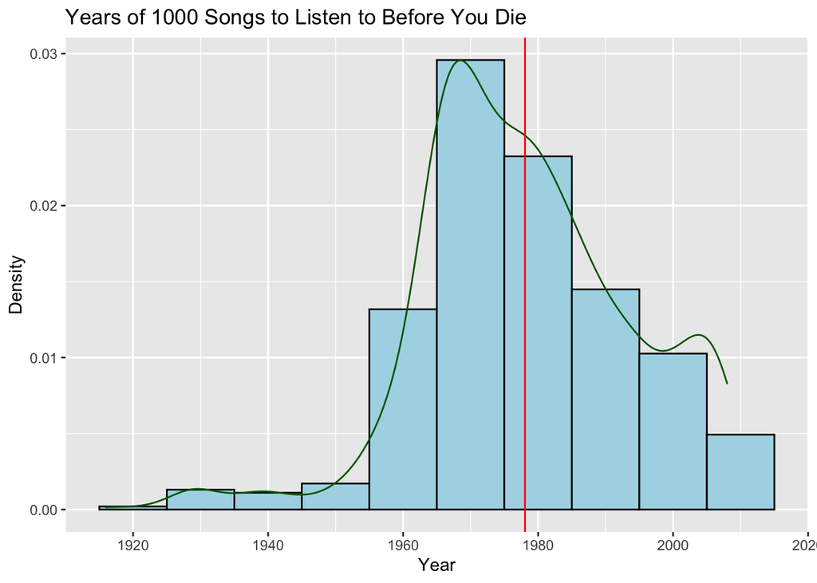

```r
ggplot(data = songs, aes(x = YEAR)) +
  geom_histogram(binwidth = 10, color = "black", fill = "lightblue", aes(y = ..density..)) +
  geom_density(color = "darkgreen") +
  geom_vline(aes(xintercept = mean(YEAR)), color = "red") + labs(title = "Years of 1000 Songs to Listen to Before You Die", x = "Year", y = "Density")
```

*The line `aes(y = ..density..)` changes the scale of the y-axis to be on the density scale, which is what the scale of the density curve is on. If we tried to remove `aes(y = ..density..)`, then we would create a histogram on the typical count scale with a density curve displayed on the density scale; the curve would not be visible because the density scale is much smaller than the count scale. To demonstrate, here’s what would happen if we removed `aes(y = ..density..)`:*

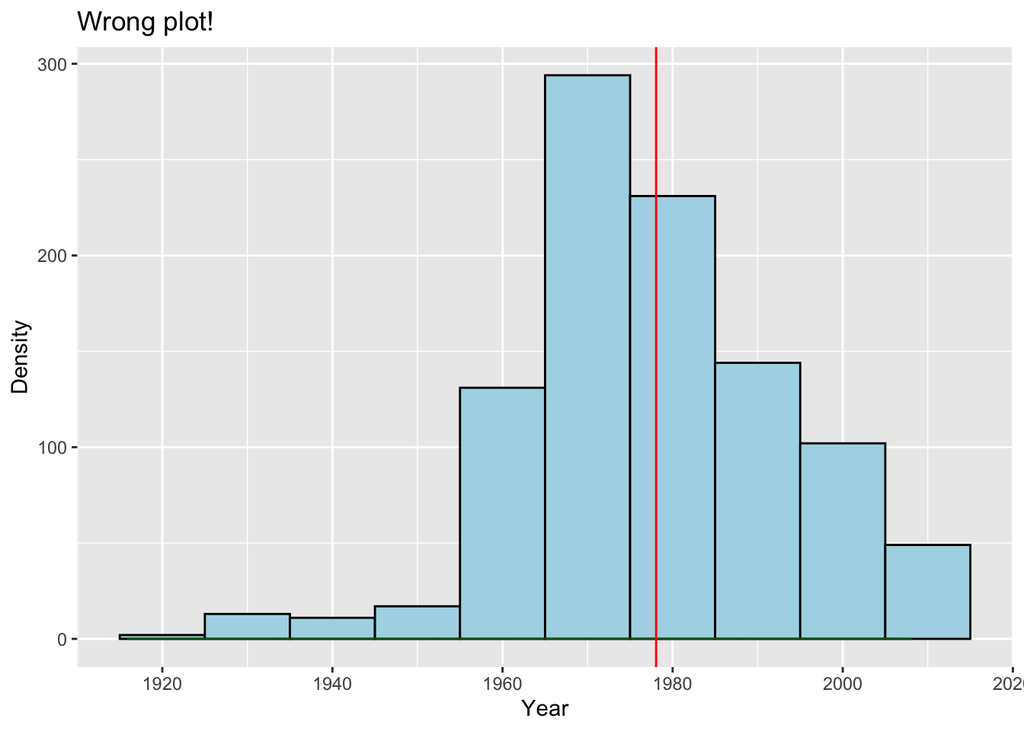

```r
ggplot(data = songs, aes(x = YEAR)) +
  geom_histogram(binwidth = 10, color = "black", fill = "lightblue") +
  geom_density(color = "darkgreen") +
  geom_vline(aes(xintercept = mean(YEAR)), color = "red") + labs(title = "Wrong plot!", x = "Year", y = "Density")
```

*If you squint at the bottom of the graph, you can barely see the green density line, which is displayed on the density scale (ranging from 0 to 0.03, which is extremely small on the count scale).*

3. (6pts) Now copy-and-paste your Part B code here. Then, add one of the following to your `ggplot` code:
- `facet_wrap(~ THEME)`
- `facet_grid(~ THEME)`
- `facet_grid(THEME ~ .)`

Choose the specification of `facet_wrap()` or `facet_grid()` that you believe gives you the best ability to compare these conditional distributions; mention why you made your choice in one sentence. **You don’t need vertical lines in this plot, so delete the piece of your code adding vertical lines, but be sure that density curves are still added to your plot.** Then, compare and contrast the different conditional distributions of `YEAR` given `THEME` in 1-4 sentences.

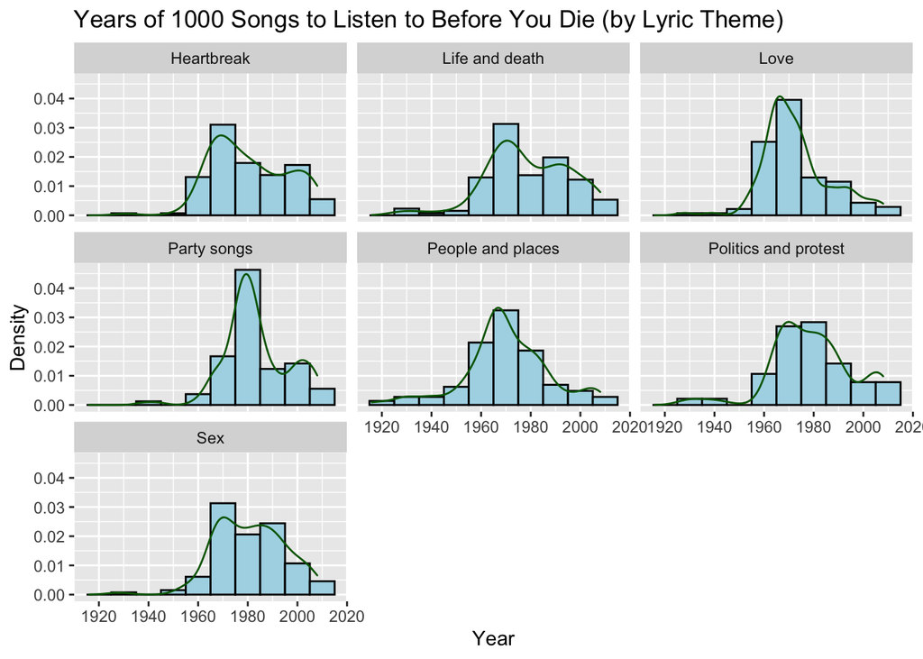

```r
ggplot(data = songs, aes(x = YEAR)) +
  geom_histogram(binwidth = 10, color = "black", fill = "lightblue", aes(y = ..density..)) +
  geom_density(color = "darkgreen") +
  facet_wrap(~ THEME) + labs(title = "Years of 1000 Songs to Listen to Before You Die (by Lyric Theme)", x = "Year", y = "Density")
```

*We chose `facet_wrap(~ THEME)` because we found that it most clearly displayed both the `THEME` labels and the `YEAR` labels. When comparing the distributions, we will focus on the density curves. First, we can see that most songs are centered around 1970, except for Party songs, which are distinctly centered around 1980. Furthermore, while most of the distributions have the same center, they appear to have fairly different spreads: Heartbreak, Life and Death, Politics and Protest, and Sex songs have a fairly large spread, while the other songs are more closely concentrated around their mode. Speaking of mode, we can see that Heartbreak, Life and Death, Party Songs, and Politics and Protest songs tend to have two modes (one at 1970 and another in the 2000s, perhaps denoting a resurgence of these themes), while the other song types have a single mode.*

*We were pretty lenient when grading this question, but because this graph displays two variables (`YEAR` and `THEME`), we expected you to comment on both. Furthermore, your interpretation should include at least some discussion of center, spread, and shape, which are the main characteristics of univariate quantitative distributions.*

4. (4pts) Let’s say that [Professor J. Bolm](https://en.wikipedia.org/wiki/Jeremy_Bolm) is taking 36-315, and he excitedly makes the following plot after listening to a 36-315 lecture:

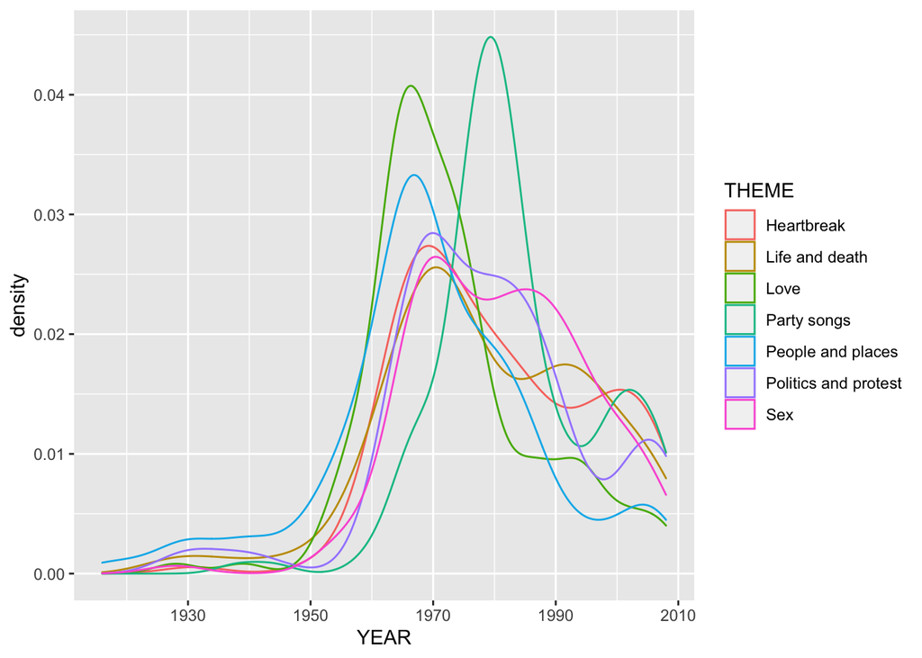

```r
library(tidyverse)
ggplot(songs, aes(x=YEAR, color=THEME)) +
  geom_density()
```

Professor Bolm makes the following argument for why he thinks this is a good plot:

“If you think about it, having histograms *and* smoothed densities is just a waste of data-ink: we really just need the smoothed density to get an idea of what the distribution is. Also, I’ve heard that overlaying smoothed densities is a great way to compare distributions, so why not just do that? I’d say my plot is better than the Part C plot for comparing different `YEAR` distributions, because it puts everything in one plot, rather than seven different plots.”

Do you agree or disagree with Professor Bolm’s argument? After saying whether you agree or disagree, explain in 1-3 sentences.

*Personally, I disagree with Professor Bolm’s argument. From this plot, it’s very difficult to pinpoint which distribution corresponds to which theme, whereas in the facetted histogram it was much easier to look at a `YEAR` distribution given a particular `THEME` (and thus it was easier for me to make comparisons). When looking at this plot, I found myself squinting a lot to determine which color was which.*

*That said, there are some benefits to this plot: We can more quickly see that there tend to be three types of distributions:*

- Distributions with a small spread and centered around the late 1960s (People and Places, Love)
- Distributions with a large spread and centered around the early 1970s (Heartbreak, Life and Death, Politics and Protest, Sex)
- Distributions with a small spread and centered around 1980 (Party)

*So, there is an argument to be made for preferring either plot; when grading this question, we were just looking for a distinct preference and an appropriate explanation for that preference.*

# Problem 2: Automatic Histograms (22 points)

As you may have seen in Problem 1A, it can be tedious to figure out what the best number of `bins` or `binwidth` is for a histogram. [Wouldn’t it be nice](https://www.youtube.com/watch?v=3y44BJgkdZs) if there was an automatic way to choose these things?

In fact, there are many automatic ways to do this! [See here](https://en.wikipedia.org/wiki/Histogram#Sturges'_formula) for many different “rules” for either choosing the number of bins $k$ or the binwidth $h$. We will consider the following rules:

- Sturges’ formula (which gives you the number of bins)
- The Rice rule (which gives you the number of bins)
- Scott’s rule (which gives you the binwidth)
- Freedman-Diaconis’ rule (which gives you the binwidth)

All of these rules are described on the Wikipedia page linked above. In fact, the `hist()` function (how you can make a histogram in `R` without `ggplot()`) already has the first, third, and fourth rules available. Unfortunately, these rules are *not* readily available in `ggplot`; however, they can be readily coded up, which is what you’ll have to do in this problem.

1. (12pts) In this part, write four functions:
- `getSturgesBinNum(x)`: Returns the number of bins according to Sturges’ rule.
- `getRiceBinNum(x)`: Returns the number of bins according to the Rice rule.
- `getScottsBinwidth(x)`: Returns the binwidth according to Scott’s rule.
- `getFDBinwidth(x)`: Returns the binwidth according to Freedman-Diaconis’ rule.

Each of these functions should take in a quantitative vector `x` (e.g., `songs$YEAR`). To get you started, there is some template code below that you can edit. **After you’ve written your functions, report what each function returns when you input `songs$YEAR`.** Here are a few other hints to help you with this problem:

- Sturges’ rule and the Rice rule involve the [ceiling function](https://en.wikipedia.org/wiki/Floor_and_ceiling_functions); the ceiling function in `R` is `ceiling(x)`.
- The Rice rule and Scott’s rule involves the cubic root; note that $\sqrt[3]{n} = n^{1/3}$, which you can type in `R`.
- Sturges’ rule also uses the $\log_2(x)$ function; this is `log2(x)` in `R`.
- Freedman-Diaconis’ rule involves the IQR, which you can compute using the `IQR()` function.

To be clear, this problem requires minimal coding; each function only requires 3-4 lines of code (some of which I already give you in the template code below). This problem is just meant to demonstrate that sometimes we can write mini functions to help us make graphs (as we will see in Part B). **Remember to report what the each function returns when you input the `songs$YEAR` variable!**

```r
#TEMPLATE CODE - MODIFY THIS
getSturgesBinNum = function(x){
    #number of observations
    n = length(x)
    #thus, the number of bins is
    k = ceiling(log2(n)) + 1
    return(k)
}
#TEMPLATE CODE - MODIFY THIS
getRiceBinNum = function(x){
    #number of observations
    n = length(x)
    #thus, the number of bins is
    k = ceiling( 2*(n^(1/3)) )
    return(k)
}
getScottsBinwidth = function(x){
    #the standard deviation is
    sigma = sd(x)
    #number of observations
    n = length(x)
    #thus, the binwidth is
    h = (3.49*sigma)/(n^(1/3))
    return(h)
}
getFDBinwidth = function(x){
  #the IQR is
    iqr = IQR(x)
    #number of observations
    n = length(x)
    #thus, the binwidth is
    h = (2*iqr)/(n^(1/3))
    return(h)
}
# REPORT WHAT YOU GET FOR EACH OF THESE FUNCTIONS HERE
getSturgesBinNum(songs$YEAR)
```

```
## [1] 11
```

```r
getRiceBinNum(songs$YEAR)
```

```
## [1] 20
```

```r
getScottsBinwidth(songs$YEAR)
```

```
## [1] 5.46093
```

```r
getFDBinwidth(songs$YEAR)
```

```
## [1] 4.008032
```

*We see that our `getSturgesBinNum()` function gave us an output of 11 bins, whereas `getRiceBinNum()` gave an output of 20 bins (almost double). Meanwhile, our `getScottsBinwidth()` function gave us an output of a 5.46 binwidth, and our `getFDBinwidth()` function gave us an output of a 4.01 binwidth.*

2. (10pts) Now make a histogram of `songs$YEAR` using each of the four rules from Part A. Specifically, make these four histograms:
- A histogram of `songs$YEAR`, specifying `bins` using Sturges’ rule.
- A histogram of `songs$YEAR`, specifying `bins` using the Rice rule.
- A histogram of `songs$YEAR`, specifying `binwidth` using Scott’s rule.
- A histogram of `songs$YEAR`, specifying `binwidth` using Freedman-Diaconis’ rule.

Make these histograms using `ggplot`, and please place four histograms in a grid by following template code below. **Be sure to add appropriate titles for each plot so that it is clear which histogram corresponds to which rule.**

After you’ve made your histograms, discuss the differences among the four histograms in 1-3 sentences.

**Remember that you need to specify `bins` for Sturges’ rule and the Rice rule but `binwidth` for the other two rules!**

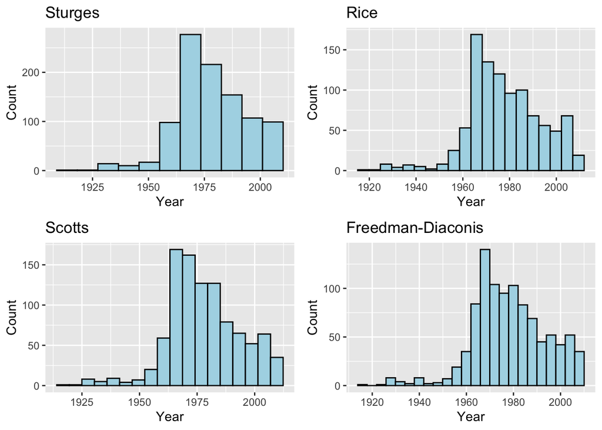

```r
#PUT YOUR CODE FOR THE STURGES PLOT HERE
sturgesBins = getSturgesBinNum(songs$YEAR)
sturgesPlot = ggplot(data = songs, aes(x = YEAR)) +
  geom_histogram(bins = sturgesBins, color = "black", fill = "lightblue") + labs(title = "Sturges", x = "Year", y = "Count")
#PUT YOUR CODE FOR THE RICE PLOT HERE
riceBins = getRiceBinNum(songs$YEAR)
ricePlot = ggplot(data = songs, aes(x = YEAR)) +
  geom_histogram(bins = riceBins, color = "black", fill = "lightblue") + labs(title = "Rice", x = "Year", y = "Count")
#PUT YOUR CODE FOR THE SCOTT PLOT HERE
scottsBinwidth = getScottsBinwidth(songs$YEAR)
scottsPlot = ggplot(data = songs, aes(x = YEAR)) +
  geom_histogram(binwidth = scottsBinwidth, color = "black", fill = "lightblue") + labs(title = "Scotts", x = "Year", y = "Count")
#PUT YOUR CODE FOR THE FREEDMAN-DIACONIS PLOT HERE
fdBinwidth = getFDBinwidth(songs$YEAR)
fdPlot = ggplot(data = songs, aes(x = YEAR)) +
  geom_histogram(binwidth = fdBinwidth, color = "black", fill = "lightblue") + labs(title = "Freedman-Diaconis", x = "Year", y = "Count")
library(gridExtra)
grid.arrange(sturgesPlot, ricePlot, scottsPlot, fdPlot)
```

*We see that—for this dataset—Sturges’ rule gave us the widest bars, whereas the other three rules gave us fairly comparable bar sizes. If we squint, we can see that the Freedman-Diaconis’ rule gave us the thinnest bars, followed by the Rice rule, and finally by Scott’s rule. In general, the overall shape of the distribution appears to be pretty similar regardless of which rule we used, which is reassuring.*

# Problem 3: Ghost in the Boxplot: Transparency Side-by-Side (21 points)

In this problem we will continue to use the `songs` dataset, this time using boxplots to visualize the dataset.

1. (4pts) First, make a boxplot of the `YEAR` variable using `geom_boxplot()`; you can place `YEAR` on the x-axis or y-axis (your choice). However, be sure that the other axis does not display any numbers, which can be otherwise distracting. Within `geom_boxplot()`, specify a `fill` color of your choice. Make sure that your plot is appropriately labeled and titled. All you need to do here is make the plot (and include your code to make the plot, of course). I won’t make you interpret the marginal distribution of `YEAR` based on this plot; we already did that earlier with histograms. (**Hint**: To make numbers not display on one of the axes, try setting that axis variable, `x` or `y`, equal to `""`.)

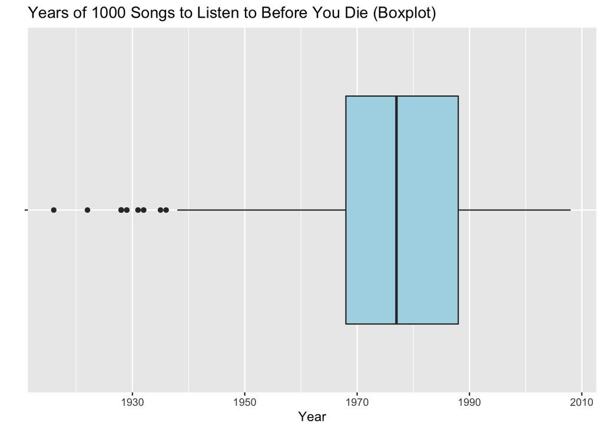

```r
ggplot(songs, aes(x = YEAR, y = "")) + geom_boxplot(fill = "lightblue") + labs(title = "Years of 1000 Songs to Listen to Before You Die (Boxplot)", x = "Year", y = "")
```

*Note that it’s important to take the time to get rid of the y-axis with `y = ""` in `aes()`. If we do not do this, then we get numbers on the y-axis that don’t mean anything (and are thus distracting):*

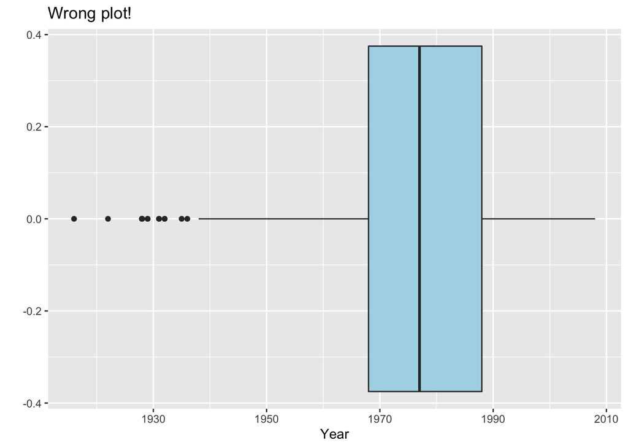

```r
ggplot(songs, aes(x = YEAR)) + geom_boxplot(fill = "lightblue") + labs(title = "Wrong plot!", x = "Year", y = "")
```

2. (4pts) Now copy-and-paste your code from Part A here, and add `alpha = .5` within `geom_boxplot()`. Compared to Part A, you should see that the box itself is somewhat transparent. However, some of the outlier dots are more transparent than others. Why does this happen? Explain in 1-3 sentences.

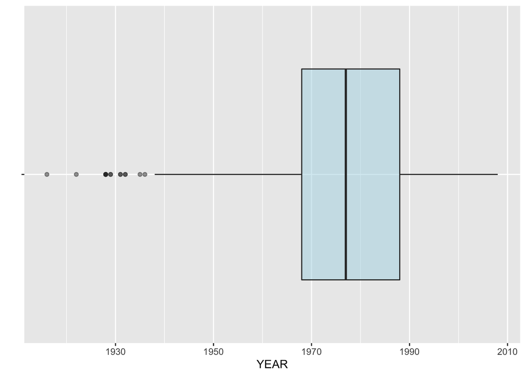

```r
ggplot(songs, aes(x = YEAR, y = "")) + geom_boxplot(fill = "lightblue", alpha = 0.5) + labs(y = "")
```

*We see that adding the alpha argument discolors some outliers more than others; this is because some years have multiple observations and they are plotted on top of one another, thereby making the dots less transparent.*

3. (5pts) For this part, copy-and-paste your code from Part B, and then change your code accordingly such that you display side-by-side boxplots showing the conditional distribution of `YEAR` given `THEME`. Furthermore, `fill` each box according to `THEME`, such that each box is colored by theme. Again make sure that your plot is appropriately titled/labeled. Your final plot should have `YEAR` on one axis, `THEME` on another axis, and the boxes colored by `THEME` (with some transparency).

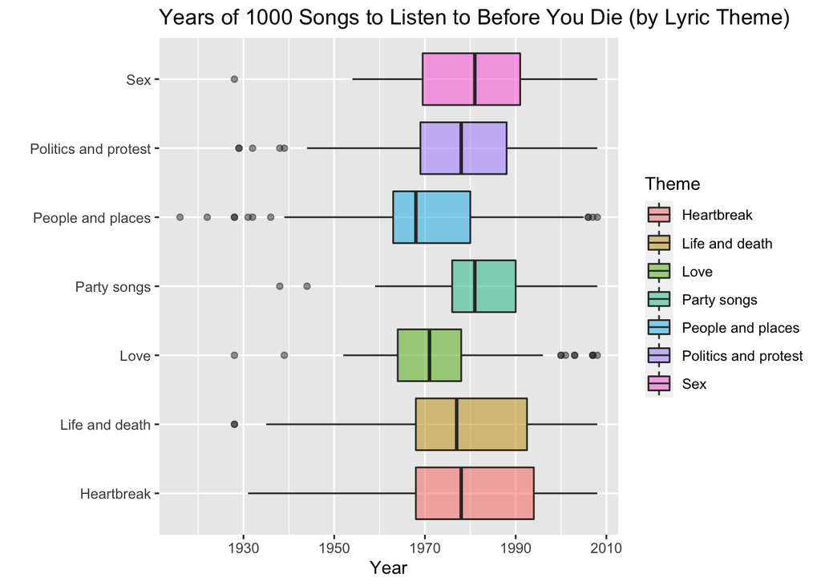

```r
ggplot(songs, aes(x = YEAR, y = THEME)) + geom_boxplot(aes(fill = THEME), alpha = 0.5) + labs(title = "Years of 1000 Songs to Listen to Before You Die (by Lyric Theme)", x = "Year", y = "") + scale_fill_discrete(name = "Theme")
```

```r
songs$decade = ifelse( songs$YEAR <= 1959, "1910s-50s",
 ifelse( songs$YEAR <= 1969, "1960s",
    ifelse( songs$YEAR <= 1979, "1970s",
        ifelse(songs$YEAR <= 1989, "1980s",
            ifelse(songs$YEAR <= 1999, "1990s", "2000s")))) )
 songs$decade = as.factor(songs$decade)
```

Now copy-and-paste your code from Part C, and change `fill` within `geom_boxplot()` to be equal to `decade`. Your final plot should have `YEAR` on one axis, `THEME` on another axis, and the boxes colored by `decade` (with some transparency). After you’ve made your plot, answer the following questions:

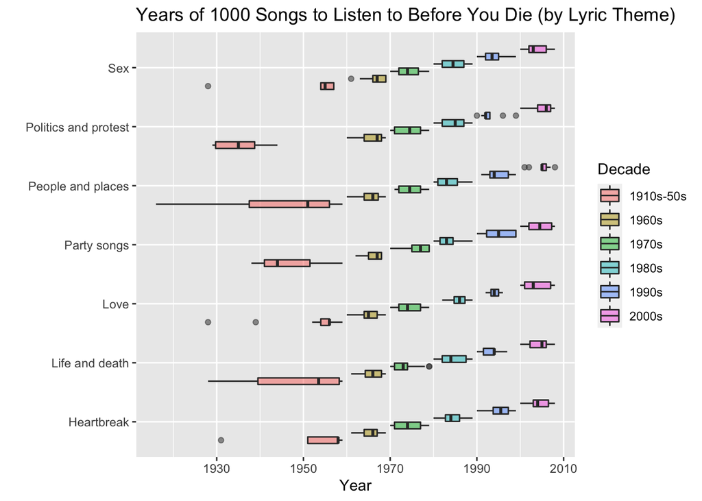

```r
ggplot(songs, aes(x = YEAR, y = THEME)) + geom_boxplot(aes(fill = decade), alpha = 0.5) + labs(title = "Years of 1000 Songs to Listen to Before You Die (by Lyric Theme)", x = "Year", y = "") + scale_fill_discrete(name = "Decade")
```

- What distribution does this plot display?

*This plot displays the conditional distribution of `YEAR` given `THEME` and `decade`.*

- What kinds of comparisons (if any) are easier to make in this plot, compared to the plot in Part C? What kinds of comparisons (if any) are harder to make in this plot, compared to the plot in Part C? Explain your answer in 1-3 sentences.

*This plot makes it easier to compare the distribution of `YEAR` across `THEME` for particular decades. However, this is generally not too informative/interesting, except possibly for the 1910s-50s decade, since this “decade” is a span of 40 years. Thus, we can see, within this decade, whether a given `THEME` had very early or late songs: For example, we see that the “People and places” theme had songs spanning this 40-year range, whereas Love, Heartbreak, and Sex songs were mostly released past 1950. (Does this mean that people before the 1950s weren’t in relationships??) Meanwhile, it’s a lot harder to see how the distribution of `YEAR` compares across `THEME` - for example, in the previous plot, we could see that Party songs tended to be released later than Love songs, but that is almost completely obfuscated in this plot.*

# Problem 4: Whining about Density Estimates and Histograms (35 points)

In this problem, we will work with a dataset of red wines. The dataset is provided [here](https://www.kaggle.com/piyushgoyal443/red-wine-dataset/data) by Kaggle. Documentation for all of the variables is available at that link as well. The help documentation is available on the Course GitHub page [here](https://raw.githubusercontent.com/zjbranson/315Fall2021/master/wineQualityInfo.txt) for reference.

Here is the code to read in the data into `R`:

```r
library(tidyverse)
wine <- read.csv("https://raw.githubusercontent.com/zjbranson/315Fall2021/master/wineQualityReds.csv")
```

The following problems focus on examining the distribution of `volatile.acidity` with density estimates and histograms.

1. (8pts) First we will plot the marginal distribution of `volatile.acidity`, and visually assess if it follows a Normal distribution. To do this, complete the following steps:
- Create a histogram of `volatile.acidity` on the **density scale**. Make the color something other than gray or black, and (as usual) be sure your plot is properly titled and labeled.

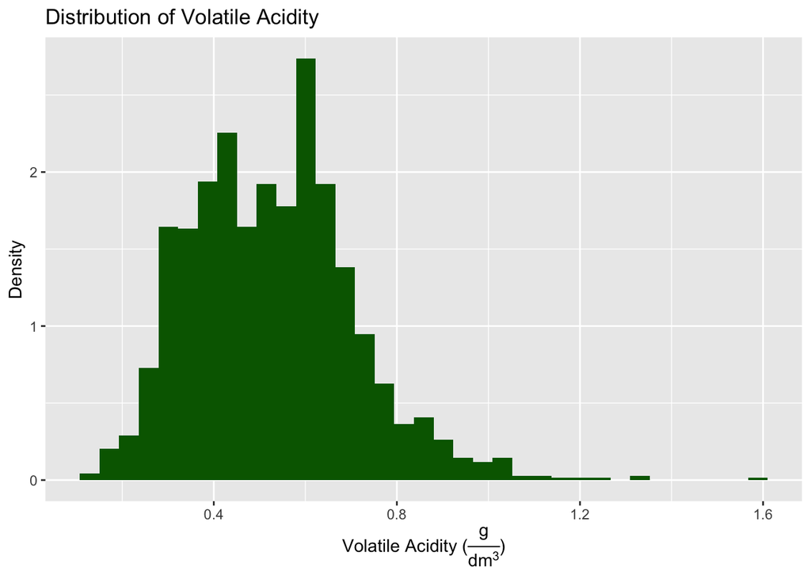

```r
library(latex2exp)
ggplot(wine, aes(x = volatile.acidity)) +
  geom_histogram(aes(y=..density..), fill = "darkgreen", bins = 35) +
  labs(title = "Distribution of Volatile Acidity",
       x = TeX("Volatile Acidity (\\frac{g}{dm^3})"),
       y = "Density")
```

- To see how well a Normal distribution fits to `volatile.acidity`, write code that defines the sample mean and variance `volatile.acidity`; define these as `mean.est` and `var.est`, respectively. Then, using the code below (that you have to modify), define the variable `acidity.normDensity`, which is the estimated Normal density for `volatile.acidity`:

```r
#first, define the mean and variance:
mean.est = mean(wine$volatile.acidity)
var.est = var(wine$volatile.acidity)
#then, compute the Normal density
wine$acidity.normDensity = dnorm(wine$volatile.acidity,
                                 mean = mean.est, sd = sqrt(var.est))
```

Currently, the above code fits a standard Normal density (with mean 0, standard deviation 1), and you need to replace the mean and sd arguments appropriately. **Remember that sd is for standard deviation, which is the square root of the variance.**

- Finally, add the Normal density curve to your histogram of `volatile.acidity`. To do this, first copy-and-paste your histogram code, and then add the line `+ geom_line(aes(volatile.acidity, acidity.normDensity))`.

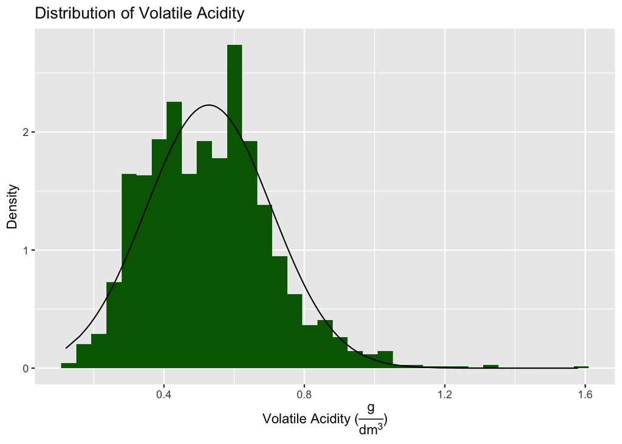

```r
ggplot(wine, aes(x = volatile.acidity)) +
  geom_histogram(aes(y=..density..), fill = "darkgreen", bins = 35) +
  geom_line(aes(volatile.acidity, acidity.normDensity)) +
  labs(title = "Distribution of Volatile Acidity",
       x = TeX("Volatile Acidity (\\frac{g}{dm^3})"),
       y = "Density")
```

Ultimately, you should end up with a histogram of `volatile.acidity` with a Normal density curve added to the plot. After you’ve made your plot, describe the distribution of `volatile.acidity` in 1-2 sentences, and then discuss whether or not you think this distribution appears to be Normally distributed (say Yes or No, and then provide a 1-2 sentence explanation).

2. (5pts) Now we’ll formally test whether `volatile.acidity` follows a Normal distribution. Do this using the Kolmogorov-Smirnov (KS) test. Specifically: Test whether `volatile.acidity` follows a Normal distribution whose mean and standard deviation are equal to the sample mean and sample standard deviation of `volatile.acidity` observed in the data, respectively. In your answer, after providing the appropriate code for the KS test, state your formal conclusion from the test.

*Here’s the code to run the appropriate KS test:*

```r
ks.test(x = wine$volatile.acidity, y = "pnorm", mean = mean.est, sd = sqrt(var.est))
```

```
##
##  One-sample Kolmogorov-Smirnov test
##
## data:  wine$volatile.acidity
## D = 0.054662, p-value = 0.0001416
## alternative hypothesis: two-sided
```

*We get a p-value of 0.0001, which is certainly less than 0.05. Thus, we reject the null hypothesis that the data follow this Normal distribution, thereby concluding that `volatile.acidity` does not appear to be Normally distributed.*

3. (6 points) Create two density plots of `volatile.acidity`. (You can use the `density` function in base `R`, or you can use the `geom_density` function in `ggplot`.) In the first plot, use a small bandwidth, so that many local features of the distribution are shown, and the density estimate is somewhat “jagged” / “rigid” / not smooth. In the second, use a larger bandwidth, so that the local features of the distribution are smoothed out. Include both plots in your answer, and compare and contrast the two plots (e.g., discuss which features are easier or more difficult to see in each of the plots) in 1-3 sentences. You may have to try a few bandwidth values to figure out what is a relatively small or large bandwidth.

Make sure that each plot is appropriately titled/labeled such that we know which is the “large bandwidth” plot and which is the “small bandwidth” plot. Furthermore, be sure to include the *units* of the `volatile.acidity` variable in your labels; you’ll have to check the data documentation to see what the units are for this variable.

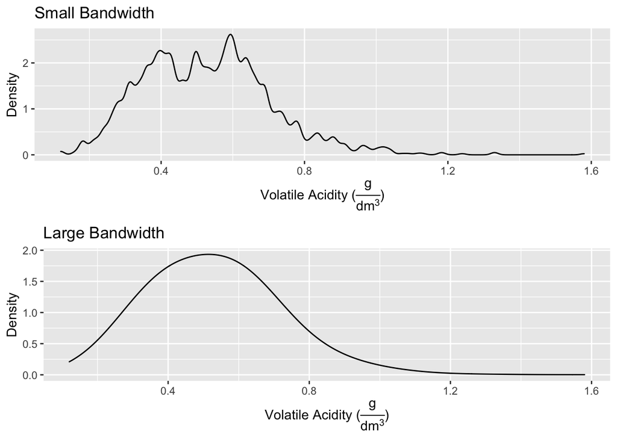

```r
library(grid); library(gridExtra)

small_band <- ggplot(wine, aes(x = volatile.acidity)) +
  geom_density(bw = 1/100) +
  labs(x = TeX("Volatile Acidity (\\frac{g}{dm^3})"),
       y = "Density",
       title = "Small Bandwidth")

large_band <- ggplot(wine, aes(x = volatile.acidity)) +
  geom_density(bw = 1/10) +
  labs(x = TeX("Volatile Acidity (\\frac{g}{dm^3})"),
       y = "Density",
       title = "Large Bandwidth")

grid.arrange(small_band, large_band, nrow = 2)
```

*In the large bandwidth plot, it’s very easy to see the mode of the distribution as well as the slight right skew. However, it does seem to hide where there are particularly higher or lower concentrations of observations within that mode, which we could more clearly see in the histogram as well as the smaller bandwidth plot. For example, in the smaller bandwidth plot, we can almost see two “sub modes” within this single mode. Interestingly, by looking at the right tail, we can also see small “bumps” where there are individual observations - thus, we are better able to see outliers in the smaller bandwidth plot.*

4. (10 points) For the remainder of this question, we will also work with the variable `quality`. Look at the help documentation for this variable. From this description, is this variable a quantitative/continuous variable, quantitative/discrete variable, categorical/nominal variable, or categorical/ordinal variable? After answering this, use the `class` function to determine what type of variable this is in `R`. In your answer, report what the class is.

*From the help documentation, we see that quality is measured on a 0-to-10 scale. Thus, it is a categorical/ordinal variable. (One could make the argument that it is a quantitative/discrete variable, but something like quality = 11 wouldn’t make sense in this context.) Here we can look at the class of quality:*

```r
class(wine$quality)
```

```
## [1] "integer"
```

*and we see that it is classified as an integer.*

Regardless of your answer, please run the following code to treat `quality` as a factor:

```r
wine <- wine %>% mutate(quality = factor(quality))
```

Then, to assess if the distribution of `volatile.acidity` differs depending on the `quality` of the wine, make four different plots:

- A “stacked histogram” of `volatile.acidity` (where the bars are colored according to the wine `quality`). To do this, first make a histogram of `volatile.acidity`, and then specify `fill` as `quality`.

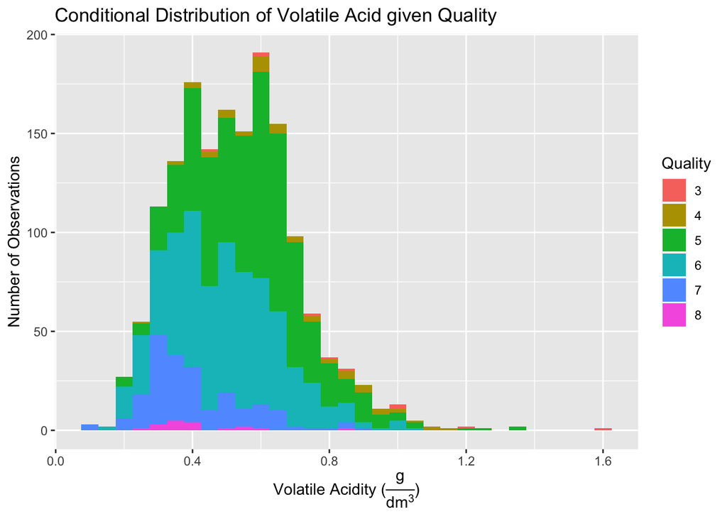

```r
stacked_hist <- ggplot(data = wine, aes(volatile.acidity, fill = quality)) +
  geom_histogram(binwidth =  0.05) +
  labs(x = TeX("Volatile Acidity (\\frac{g}{dm^3})"),
       y = "Number of Observations",
       title = "Conditional Distribution of Volatile Acid given Quality",
       fill = "Quality")

stacked_hist
```

- A “conditional density plot,” where there are six density curves of `volatile.acidity` – one for each wine quality grade – on a single plot, with each curve colored according to the wine quality). Let `R` choose the bandwidth automatically.

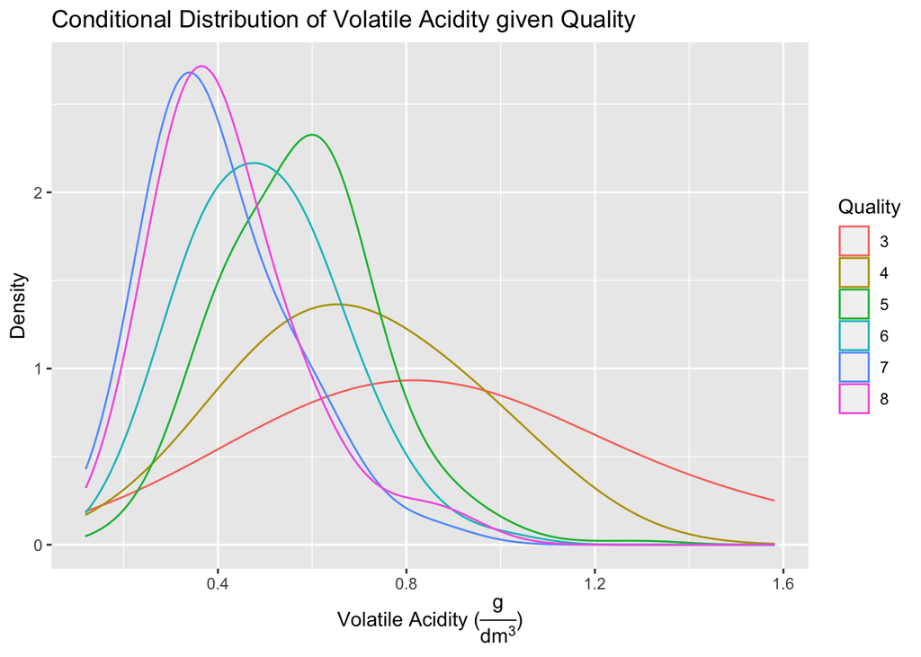

```r
cond_dens <- ggplot(wine, aes(x = volatile.acidity, color = quality)) +
  geom_density(adjust = 2) +
  labs(x = TeX("Volatile Acidity (\\frac{g}{dm^3})"),
       y = "Density",
       title = "Conditional Distribution of Volatile Acidity given Quality",
       color = "Quality")

cond_dens
```

- Facetted histograms of `volatile.acidity`, facetted by `quality`.

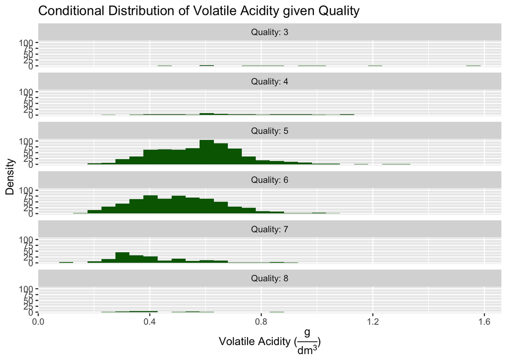

```r
facetted_histogram <- wine %>%
  mutate(quality = factor(quality,
             levels = c("3", "4", "5", "6", "7", "8"),
             labels = c("Quality: 3", "Quality: 4", "Quality: 5",
                        "Quality: 6", "Quality: 7", "Quality: 8"))) %>%
  ggplot(aes(x = volatile.acidity)) +
  geom_histogram(bins = 30, fill = "darkgreen") +
  facet_wrap( ~ factor(quality), ncol = 1) +
  labs(x = TeX("Volatile Acidity (\\frac{g}{dm^3})"),
        y = "Density",
        title = "Conditional Distribution of Volatile Acidity given Quality")

facetted_histogram
```

- Side-by-side boxplots of `volatile.acidity` (one “box” for each value of `quality`). Also, `fill` the boxplots by `quality`.

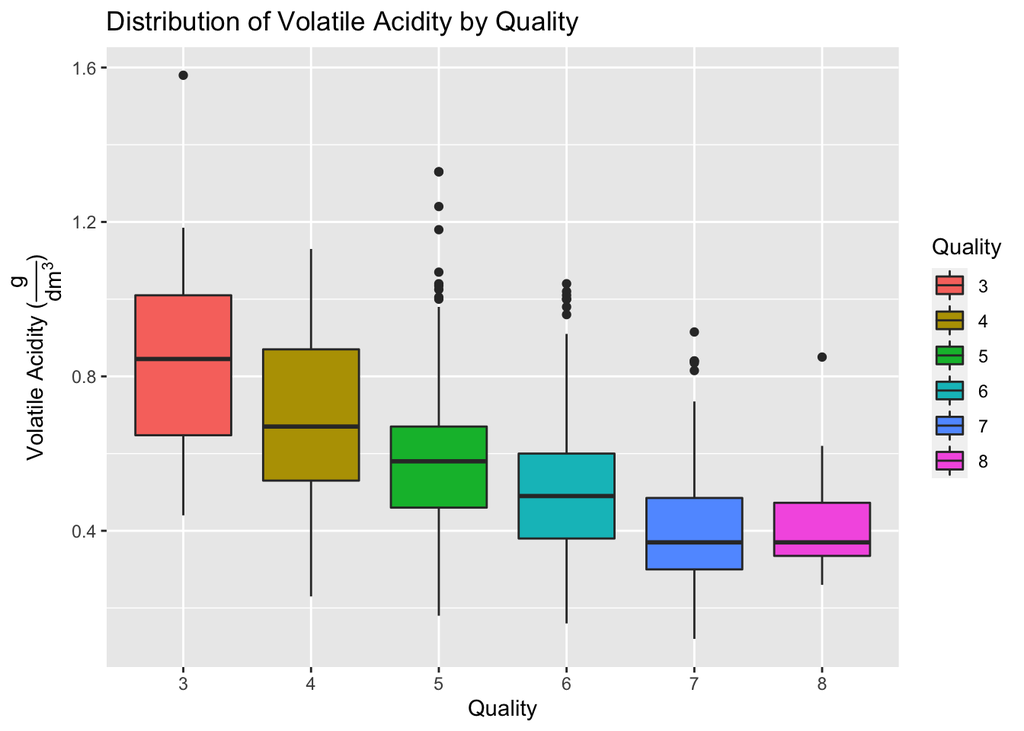

```r
ggplot(wine, aes(x = quality, y = volatile.acidity,
                          fill = quality)) +
    geom_boxplot() +
    labs(x = "Quality", y = TeX("Volatile Acidity (\\frac{g}{dm^3})"), fill = "Quality",
         title = "Distribution of Volatile Acidity by Quality")
```

Make sure that each plot is appropriately titled/labeled.

All you have to do for this part is create the four plots above (as well as answer the preliminary questions about `quality`). We’ll interpret the plots in the next part.

5. (6pts) After looking at your graphs in Part D, [Professor D. Brown](https://en.wikipedia.org/wiki/Danny_Brown) asks you: “Do you think the distribution of `volatile.acidity` depends on the quality of the wine?” Use one or more of your graphs in Part D to answer this question in 1-4 sentences. Be sure that your answer discusses whether the center, spread, and shape of `volatile.acidity` depend (or not depend) on `quality`, and mention which graph(s) you used to arrive at each of your observations.

*Yes - from the graphs, it does appear that the distribution of `volatile.acidity` depends on the `quality` of the wine. First, looking at the side-by-side boxplot, it appears there is a negative relationship between `volatile.acidity` and `quality`, in the sense that a higher quality wine tends to have a lower level of `volatile.acidity`. Meanwhile, by looking at the stacked histogram and smoothed density plot, we can see that the distribution of `volatile.acidity` is fairly unimodal regardless of the wine `quality`, thereby validating our focus on the center of the distribution from the side-by-side boxplot. Furthermore, from the side-by-side boxplot, we can see that higher quality wines tend to have less spread/variance in their `volatile.acidity`, but this may in part be due to the difference in sample size, as we can see by the facetted histogram (it seems like most wines are either of `quality` 5 or 6).*